# Final Assignment Survival Analysis

202430527 이태녕

2025-12-16

# 1 예비 분석 및 Kaplan-Meier 곡선

## 1.1 데이터 로드 및 전처리

본 데이터는 원발성 담즙성 간경변증(PBC) 임상 시험 자료로 총 308개의 관측치와 14개의 변수로 구성된다. 문제에서 제시된 코딩 기준에 따라 데이터를 전처리하였다.

- **Status**: 0=중도절단(Censored), 1=사망(Event)
- **Age**: 일(Days) 단위를 연(Years) 단위로 환산
- **범주형 변수**: 분석 용이성을 위해 Factor 변환 및 라벨링 수행

```r
# 1. 데이터 로드
pbc_raw <- read.table("PBC_data.txt", header = FALSE)

# 2. 변수명 지정
colnames(pbc_raw) <- c("fu.days", "status", "drug", "age_days", "sex",
                       "ascites", "hepatom", "edema", "bili", "albumin",
                       "alk.phos", "sgot", "platelet", "protime")

# 3. 전처리 및 변환
pbc_clean <- pbc_raw %>%
  mutate(
    age = age_days / 365,
    drug_f = factor(drug, levels = c(0, 1), labels = c("DPCA", "Placebo")),
    sex_f = factor(sex, levels = c(0, 1), labels = c("Male", "Female")),
    ascites_f = factor(ascites, levels = c(0, 1), labels = c("No", "Yes")),
    hepatom_f = factor(hepatom, levels = c(0, 1), labels = c("No", "Yes")),
    edema_f = factor(edema, levels = c(0, 1, 2), labels = c("No Edema", "Untreated", "Resistant"))
  ) %>%
  select(-age_days)
pbc_clean$status_f <- factor(pbc_clean$status, levels = c(0, 1),
                             labels = c("Censored", "Event"))

# 4. 기술통계량
## 연속형
cont_vars <- c("fu.days", "age", "bili", "albumin", "alk.phos", "sgot", "platelet", "protime")

cont_desc <- do.call(rbind, lapply(cont_vars, function(v){
  x <- pbc_clean[[v]]
  c(
    N = sum(!is.na(x)),
    Mean = mean(x, na.rm = TRUE),
    SD = sd(x, na.rm = TRUE),
    Median = median(x, na.rm = TRUE),
    Q1 = unname(quantile(x, 0.25, na.rm = TRUE)),
    Q3 = unname(quantile(x, 0.75, na.rm = TRUE)),
    Min = min(x, na.rm = TRUE),
    Max = max(x, na.rm = TRUE)
  )
}))

cont_desc <- data.frame(Variable = cont_vars, round(cont_desc, 3), row.names = NULL)
print(cont_desc)
```

```
##   Variable   N     Mean       SD   Median       Q1       Q3     Min       Max
## 1  fu.days 308 1990.490 1118.469 1829.000 1185.750 2671.750  41.000  4556.000
## 2      age 308   49.981   10.583   49.829   41.939   56.685  26.296    78.493
## 3     bili 308    3.289    4.550    1.400    0.800    3.500   0.300    28.000
## 4  albumin 308    3.515    0.420    3.550    3.308    3.790   1.960     4.640
## 5 alk.phos 308 1980.206 2140.182 1264.000  871.500 1980.000 289.000 13862.400
## 6     sgot 308  123.159   56.776  116.250   81.650  151.900  26.350   457.250
## 7 platelet 308  261.935   95.609  257.000  199.750  322.500  62.000   563.000
## 8  protime 308   10.733    1.005   10.600   10.000   11.125   9.000    17.100
```

```r
##범주형
cat_vars <- c("status_f", "drug_f", "sex_f", "ascites_f", "hepatom_f", "edema_f")

cat_desc <- do.call(rbind, lapply(cat_vars, function(v){
  x <- pbc_clean[[v]]
  tab <- table(x, useNA = "ifany")
  prop <- prop.table(tab)
  data.frame(
    Variable = v,
    Level = names(tab),
    Count = as.integer(tab),
    Percent = round(100 * as.numeric(prop), 1),
    row.names = NULL
  )
}))
print(cat_desc)
```

```
##     Variable     Level Count Percent
## 1   status_f  Censored   184    59.7
## 2   status_f     Event   124    40.3
## 3     drug_f      DPCA   156    50.6
## 4     drug_f   Placebo   152    49.4
## 5      sex_f      Male    35    11.4
## 6      sex_f    Female   273    88.6
## 7  ascites_f        No   284    92.2
## 8  ascites_f       Yes    24     7.8
## 9  hepatom_f        No   151    49.0
## 10 hepatom_f       Yes   157    51.0
## 11   edema_f  No Edema   259    84.1
## 12   edema_f Untreated    29     9.4
## 13   edema_f Resistant    20     6.5
```

## 1.2 전체 생존 곡선 (Kaplan-Meier)

전체 환자의 생존 함수 추정 결과는 아래와 같다.

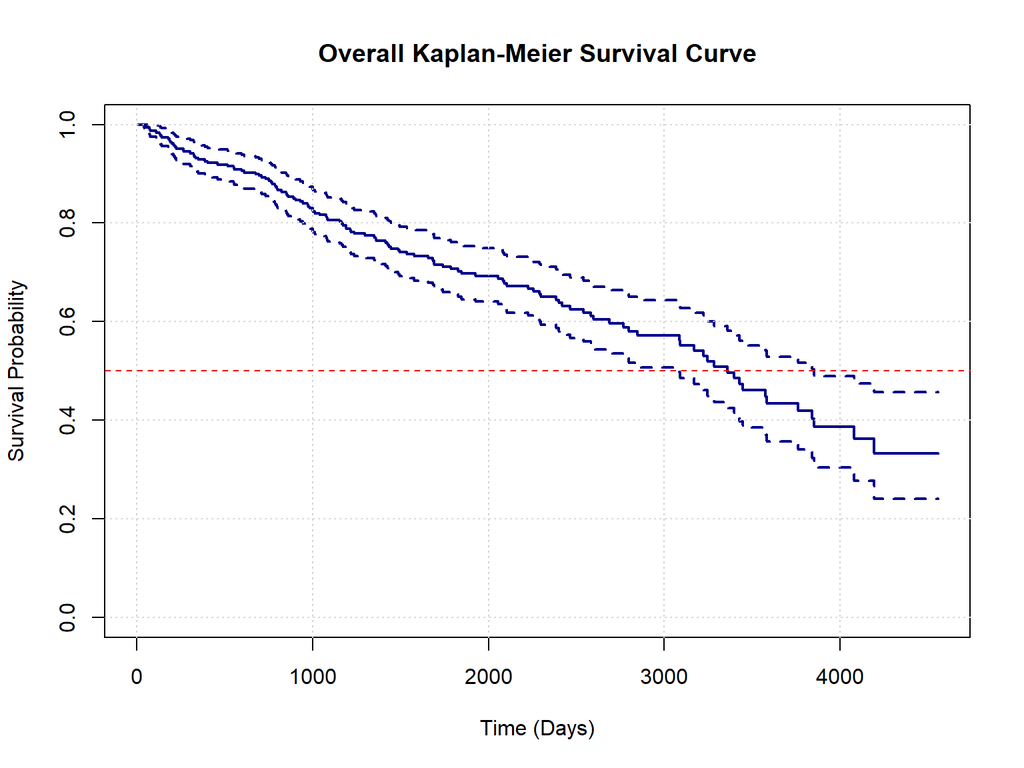

```r
fit_overall <- survfit(Surv(fu.days, status) ~ 1, data = pbc_clean)

plot(fit_overall,
     main = "Overall Kaplan-Meier Survival Curve",
     xlab = "Time (Days)", ylab = "Survival Probability",
     col = "darkblue", lwd = 2, conf.int = TRUE)
grid()
abline(h = 0.5, col = "red", lty = 2)
```

## 1.3 범주형 변수별 KM 곡선 및 로그랭크 검정

### 1.3.1 치료제(Drug) 효과 분석

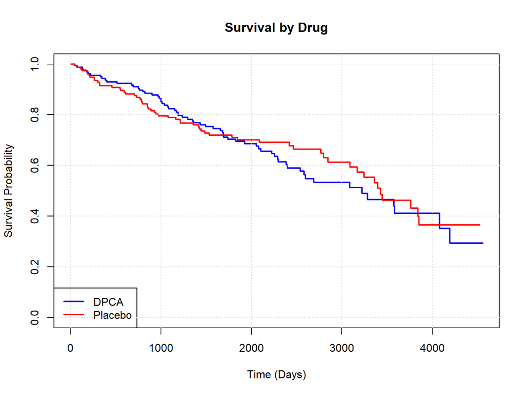

```r
fit_drug <- survfit(Surv(fu.days, status) ~ drug_f, data = pbc_clean)

plot(fit_drug, col = c("blue", "red"), lwd = 2,
     main = "Survival by Drug",
     xlab = "Time (Days)", ylab = "Survival Probability")
legend("bottomleft", legend = levels(pbc_clean$drug_f), col = c("blue", "red"), lty = 1, lwd = 2)
grid()
```

```r
# Log-rank test
sd_drug <- survdiff(Surv(fu.days, status) ~ drug, data = pbc_clean)
print(sd_drug)
```

```
## Call:
## survdiff(formula = Surv(fu.days, status) ~ drug, data = pbc_clean)
##
##          N Observed Expected (O-E)^2/E (O-E)^2/V
## drug=0 156       65     62.4     0.111     0.224
## drug=1 152       59     61.6     0.112     0.224
##
##  Chisq= 0.2  on 1 degrees of freedom, p= 0.6
```

**해석**: 로그랭크 검정 결과 p-value가 0.05보다 크다. 따라서 DPCA 투여군과 위약(Placebo)군 간의 생존율 차이는 통계적으로 유의하지 않다.

### 1.3.2 부종(Edema) 상태 분석

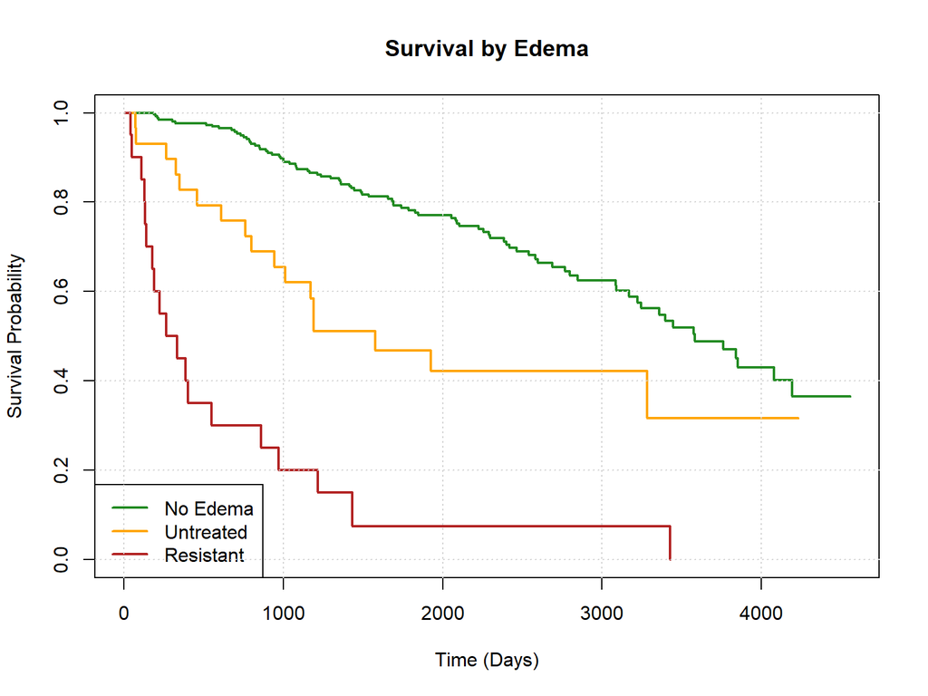

```r
fit_edema <- survfit(Surv(fu.days, status) ~ edema_f, data = pbc_clean)

plot(fit_edema, col = c("forestgreen", "orange", "firebrick"), lwd = 2,
     main = "Survival by Edema",
     xlab = "Time (Days)", ylab = "Survival Probability")
legend("bottomleft", legend = levels(pbc_clean$edema_f),
       col = c("forestgreen", "orange", "firebrick"), lty = 1, lwd = 2)
grid()
```

```r
# Log-rank test
sd_edema <- survdiff(Surv(fu.days, status) ~ edema, data = pbc_clean)
print(sd_edema)
```

```
## Call:
## survdiff(formula = Surv(fu.days, status) ~ edema, data = pbc_clean)
##
##           N Observed Expected (O-E)^2/E (O-E)^2/V
## edema=0 259       88   112.22      5.23     55.42
## edema=1  29       17     9.32      6.32      6.85
## edema=2  20       19     2.45    111.58    115.10
##
##  Chisq= 125  on 2 degrees of freedom, p= <2e-16
```

**해석**: 로그랭크 검정 결과 p-value가 매우 작게 나타났다($p < 0.001$). 부종 상태에 따라 생존율에 유의한 차이가 존재한다.

# 2 비례위험(PH) 가정 검정

## 2.1 단변량 Cox 모형 및 Schoenfeld 잔차

각 변수에 대해 단변량 Cox 모형 적합 후 `cox.zph`를 이용해 PH 가정을 검정하였다.

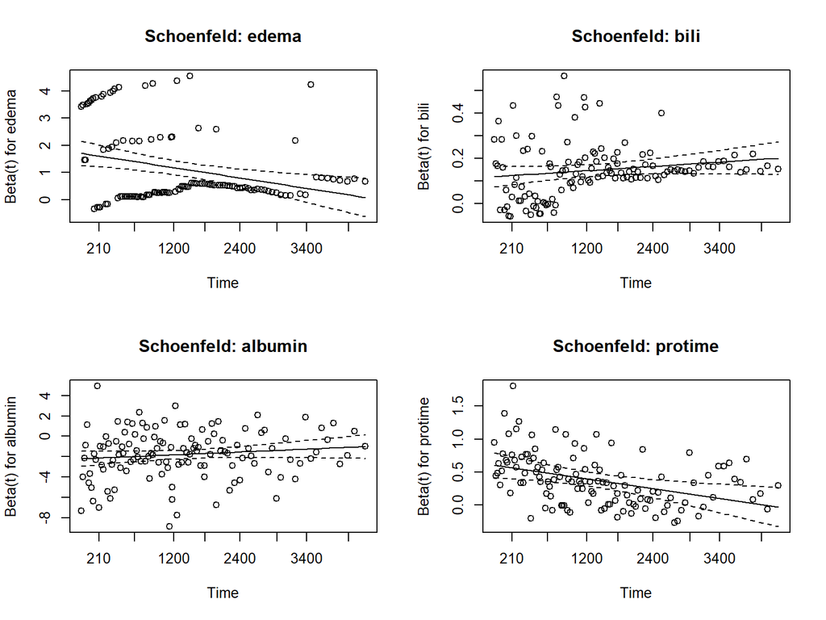

```r
covariates <- c("drug", "age", "sex", "ascites", "hepatom", "edema",
                "bili", "albumin", "alk.phos", "sgot", "platelet", "protime")

ph_results <- data.frame(Variable = character(), P_Value = numeric(), Status = character(), stringsAsFactors = FALSE)

par(mfrow = c(2, 2))
for(var in covariates) {
  f <- as.formula(paste("Surv(fu.days, status) ~", var))
  fit <- coxph(f, data = pbc_clean)
  zph <- cox.zph(fit)
  p_val <- zph$table[1, 3]

  ph_results[nrow(ph_results) + 1, ] <- list(
    var,
    round(p_val, 4),
    ifelse(p_val > 0.05, "Satisfied", "Violated")
  )

  # P-value < 0.1 인 경우 잔차 plot 확인
  if(p_val < 0.1) {
     plot(zph, main = paste("Schoenfeld:", var), df=2)
  }
}
```

```r
par(mfrow = c(1, 1))

print("--- Schoenfeld 잔차 검정 결과 ---")
```

```
## [1] "--- Schoenfeld 잔차 검정 결과 ---"
```

```r
print(ph_results)
```

```
##    Variable P_Value    Status
## 1      drug  0.3173 Satisfied
## 2       age  0.2535 Satisfied
## 3       sex  0.8954 Satisfied
## 4   ascites  0.1029 Satisfied
## 5   hepatom  0.3855 Satisfied
## 6     edema  0.0008  Violated
## 7      bili  0.0013  Violated
## 8   albumin  0.0726 Satisfied
## 9  alk.phos  0.6279 Satisfied
## 10     sgot  0.5362 Satisfied
## 11 platelet  0.1033 Satisfied
## 12  protime  0.0014  Violated
```

## 2.2 loglog Plots

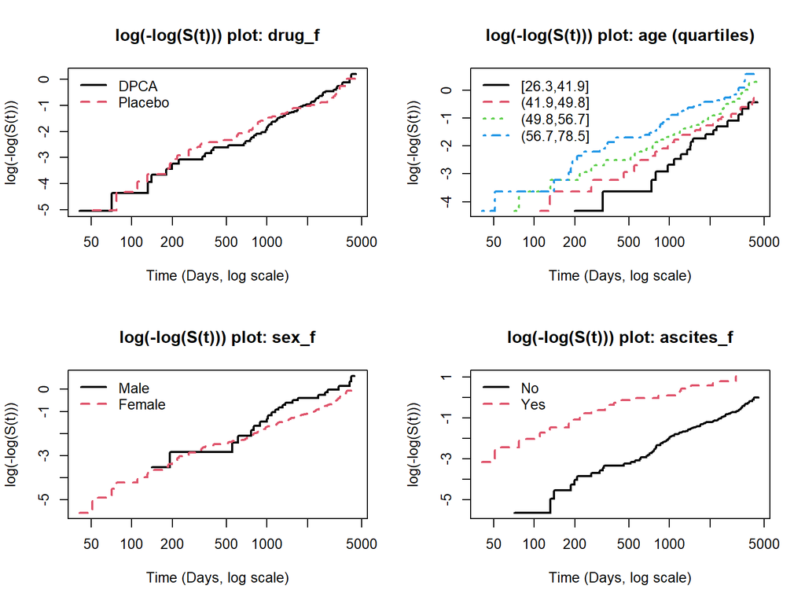

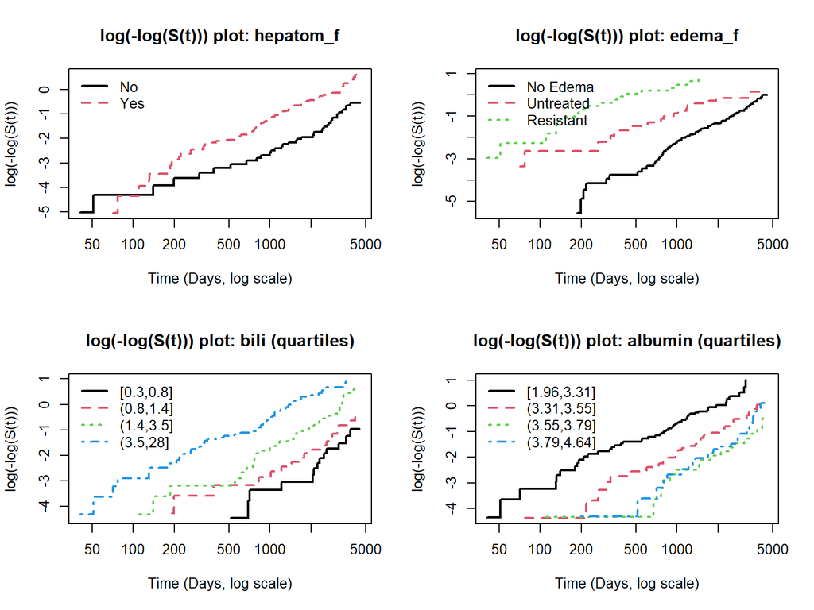

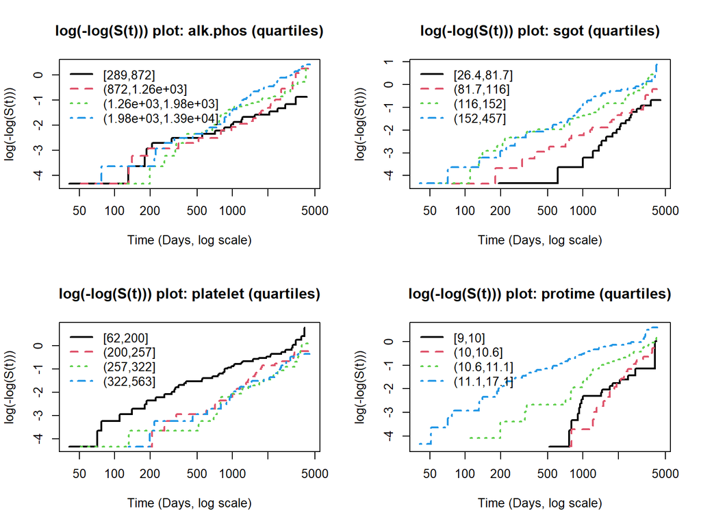

```r
plot_cloglog <- function(var, data, time = "fu.days", event = "status", ngroup = 4){
  x <- data[[var]]

  # 연속형이면 분위수로 그룹화
  if (is.numeric(x) && length(unique(x)) > 6) {
    qs <- unique(quantile(x, probs = seq(0, 1, length.out = ngroup + 1), na.rm = TRUE))
    if (length(qs) < 3) {
      grp <- factor(x)
      grp_name <- paste0(var, " (as factor)")
    } else {
      grp <- cut(x, breaks = qs, include.lowest = TRUE)
      grp_name <- paste0(var, " (quartiles)")
    }
  } else {
    grp <- factor(x)
    grp_name <- var
  }

  tmp <- data
  tmp$.__grp__ <- grp

  f <- as.formula(paste0("Surv(", time, ",", event, ") ~ .__grp__"))
  fit <- survfit(f, data = tmp)

  # strata 개수
  n <- if (is.null(fit$strata)) 1 else length(fit$strata)

  # 선 스타일/색을 strata마다 다르게
  lty_vec <- rep(1:6, length.out = n)   # 1~6 반복
  col_vec <- 1:n                       # 1,2,3,... (기본 팔레트)

  plot(fit,
       fun = "cloglog", log = "x",
       lty = lty_vec, col = col_vec, lwd = 2,
       xlab = "Time (Days, log scale)",
       ylab = "log(-log(S(t)))",
       main = paste0("log(-log(S(t))) plot: ", grp_name))

  legend("topleft", legend = levels(grp),
         lty = lty_vec, col = col_vec, lwd = 2, bty = "n")
}

covariates_for_plot <- c(
  "drug_f", "age", "sex_f", "ascites_f", "hepatom_f", "edema_f",
  "bili", "albumin", "alk.phos", "sgot", "platelet", "protime"
)

op <- par(mfrow = c(2, 2))
for (v in covariates_for_plot) {
  plot_cloglog(v, pbc_clean)
}
```

```r
par(op)
```

## 2.3 변수 분류

유의수준 0.05 기준으로 변수를 분류하였다.

```r
vars_ok <- ph_results$Variable[ph_results$Status == "Satisfied"]
vars_no <- ph_results$Variable[ph_results$Status == "Violated"]

cat("PH 가정 만족 (표준 Cox 모형):", paste(vars_ok, collapse = ", "), "\n")
```

```
## PH 가정 만족 (표준 Cox 모형): drug, age, sex, ascites, hepatom, albumin, alk.phos, sgot, platelet
```

```r
cat("PH 가정 위배 (확장 Cox 모형):", paste(vars_no, collapse = ", "), "\n")
```

```
## PH 가정 위배 (확장 Cox 모형): edema, bili, protime
```

# 3 생존 모형 구축

## 3.1 다변량 Cox PH 모형 (표준)

PH 가정을 만족하는 변수만을 사용하여 다변량 모형을 적합하였다.

```r
f_multi <- as.formula(paste("Surv(fu.days, status) ~", paste(vars_ok, collapse = " + ")))
fit_std <- coxph(f_multi, data = pbc_clean)

# 결과 정리
res_std <- summary(fit_std)$coefficients
res_conf <- summary(fit_std)$conf.int

final_table <- data.frame(
  Variable = rownames(res_std),
  Coef = round(res_std[,1], 4),
  HR = round(res_std[,2], 4),
  Lower_95 = round(res_conf[,3], 4),
  Upper_95 = round(res_conf[,4], 4),
  P_Value = round(res_std[,5], 4)
)

print("--- 다변량 Cox 모형 결과 (PH 만족 변수) ---")
```

```
## [1] "--- 다변량 Cox 모형 결과 (PH 만족 변수) ---"
```

```r
print(final_table)
```

```
##          Variable    Coef     HR Lower_95 Upper_95 P_Value
## drug         drug  0.0395 1.0403   0.7168   1.5098  0.8354
## age           age  0.0316 1.0321   1.0121   1.0525  0.0015
## sex           sex -0.1347 0.8740   0.5244   1.4565  0.6052
## ascites   ascites  1.1125 3.0420   1.7188   5.3838  0.0001
## hepatom   hepatom  0.7656 2.1502   1.4128   3.2726  0.0004
## albumin   albumin -1.0443 0.3520   0.2215   0.5592  0.0000
## alk.phos alk.phos  0.0000 1.0000   1.0000   1.0001  0.4389
## sgot         sgot  0.0057 1.0057   1.0033   1.0081  0.0000
## platelet platelet  0.0000 1.0000   0.9979   1.0021  0.9776
```

### 3.1.1 주요 결과 해석

1. **Age (나이)**: HR이 1보다 크며 통계적으로 유의하다. 나이가 증가할수록 사망 위험이 증가한다.
2. **Albumin**: HR이 1보다 작고 유의하다. 알부민 수치가 높을수록 사망 위험이 감소한다.
3. **Ascites (복수)**: HR이 3에 가까우며 복수가 있는 환자(1)는 없는 환자(0)에 비해 사망 위험이 높다.
4. **Hepatom (간비대)**: HR이 2에 가까우며 간비대가 있는 환자(1)는 없는 환자(0)에 비해 사망 위험이 높다.

## 3.2 확장 Cox 모형 (Extended Cox Model)

```r
if(length(vars_no) > 0) {
  # 기본 식에 tt(위배변수) 추가
  form_ext_str <- paste("Surv(fu.days, status) ~", paste(vars_ok, collapse = " + "))

  for(v in vars_no) {
    form_ext_str <- paste(form_ext_str, "+ tt(", v, ")")
  }

  fit_ext <- coxph(as.formula(form_ext_str),
                   data = pbc_clean,
                   tt = function(x, t, ...) x * log(t))

  # 결과 일부 출력
  coef_ext <- summary(fit_ext)$coefficients

  print("--- 확장 Cox 모형 계수 (시간 상호작용항 포함) ---")
  print(round(coef_ext[, c(1, 2, 5)], 4))

} else {
  fit_ext <- fit_std
  print("PH 위배 변수 없음.")
}
```

```
## [1] "--- 확장 Cox 모형 계수 (시간 상호작용항 포함) ---"
##                coef exp(coef) Pr(>|z|)
## drug         0.0178    1.0180   0.9247
## age          0.0334    1.0340   0.0010
## sex         -0.3692    0.6913   0.1652
## ascites      0.5252    1.6908   0.0866
## hepatom      0.5046    1.6563   0.0211
## albumin     -0.8803    0.4147   0.0011
## alk.phos     0.0000    1.0000   0.8794
## sgot         0.0046    1.0046   0.0042
## platelet     0.0000    1.0000   0.9899
## tt(edema)    0.0573    1.0590   0.0242
## tt(bili)     0.0148    1.0149   0.0000
## tt(protime)  0.0347    1.0353   0.0036
```

## 3.3 모형 비교

AIC를 기준으로 두 모형의 적합도를 비교한다.

```r
aic_std <- AIC(fit_std)
aic_ext <- AIC(fit_ext)

comp_df <- data.frame(
  Model = c("Standard Cox", "Extended Cox"),
  AIC = round(c(aic_std, aic_ext), 2)
)

print("--- Model Comparison by AIC ---")
```

```
## [1] "--- Model Comparison by AIC ---"
```

```r
print(comp_df)
```

```
##          Model     AIC
## 1 Standard Cox 1154.24
## 2 Extended Cox 1110.98
```

**결론**: 확장 Cox 모형의 AIC가 더 낮다. 해당 변수들의 시간 가변성을 고려하는 것이 타당하다는 것을 의미한다.

# 4 모형 진단 및 결론

## 4.1 잔차 분석

최종 모형(시각화를 위해 표준 모형 기준)에 대한 잔차를 확인하였다.

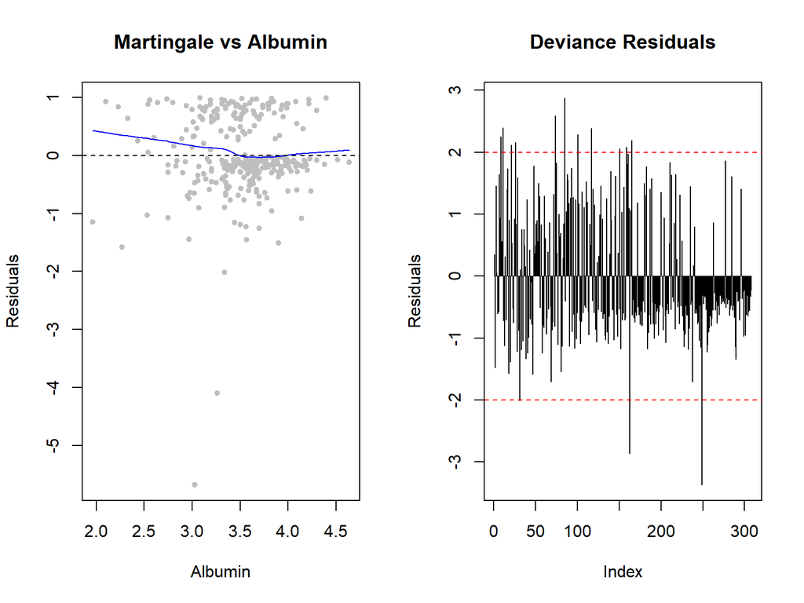

```r
par(mfrow=c(1,2))
# 1. Martingale Residuals
res_mart <- residuals(fit_std, type = "martingale")
plot(pbc_clean$albumin, res_mart, main = "Martingale vs Albumin",
     xlab = "Albumin", ylab = "Residuals", pch = 20, col = "gray")
lines(lowess(pbc_clean$albumin, res_mart), col = "blue")
abline(h=0, lty=2)

# 2. Deviance Residuals
res_dev <- residuals(fit_std, type = "deviance")
plot(res_dev, type = "h", main = "Deviance Residuals",
     xlab = "Index", ylab = "Residuals")
abline(h=c(-2,2), col="red", lty=2)
```

```r
fit_final <- fit_ext
par(mfrow=c(1,1))

# dfbeta: (n x p) 행렬
dfb <- residuals(fit_final, type = "dfbeta")

# 계수 이름(= dfbeta 열의 정체)을 모형에서 가져오기
cn <- names(coef(fit_final))

# 길이 맞으면 그대로 붙이기
colnames(dfb) <- cn

# 변수별로 |dfbeta| 최대값 큰 관측치 확인
max_abs <- apply(abs(dfb), 2, max)
sort(max_abs, decreasing=TRUE)
```

```
##      albumin      ascites          sex      hepatom         drug    tt(edema)
## 1.018854e-01 9.633141e-02 7.210939e-02 5.304022e-02 3.480179e-02 6.758380e-03
##  tt(protime)          age     tt(bili)         sgot     platelet     alk.phos
## 4.612722e-03 2.266861e-03 1.004831e-03 4.929555e-04 2.870149e-04 1.331026e-05
```

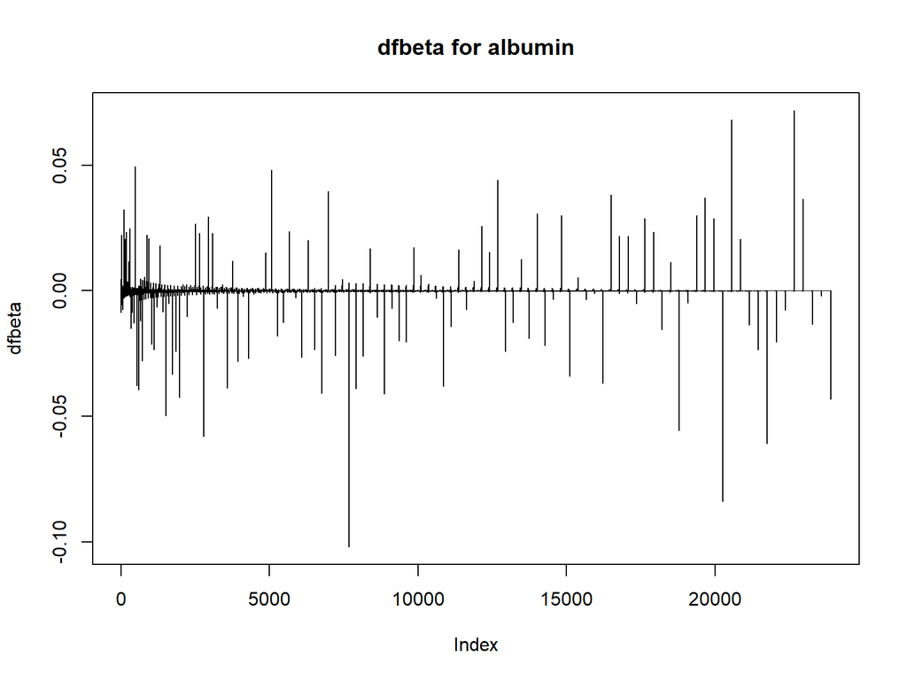

```r
# 가장 영향 큰 계수 하나를 골라 plot
j <- which.max(max_abs)
plot(dfb[, j], type="h", main=paste0("dfbeta for ", colnames(dfb)[j]),
     xlab="Index", ylab="dfbeta")
abline(h=c(-0.2,0.2), lty=2)
```

## 4.2 최종 결론

1. **유의한 변수**: 확장 Cox 모형에서 Age(+), Albumin(−), Hepatom(+), **SGOT(+)**가 유의했으며, PH 위배 변수인 Edema, Bilirubin, Protime은 log(time)과의 상호작용항(tt)이 유의하여 시간에 따라 효과가 변하는(time-varying) 위험요인임을 시사한다.
2. **영향의 방향**:
   - Age: 1년 증가할수록 위험 증가(HR>1).
   - Albumin: 수치가 높을수록 위험 감소(HR<1).
   - Hepatom: 간비대가 있는 경우 위험 증가.
   - Edema/Bilirubin/Protime: $\beta(t) = \theta log(t)$ 형태의 상호작용이 유의하고 θ>0이므로, 시간이 지날수록(추적 시간이 길어질수록) 해당 변수 증가가 위험을 더 크게 키운다.
3. **모형 선택**: 일부 변수의 비례위험 가정 위배를 해결하기 위해 **확장 Cox 모형**을 적용하였으며, 이는 표준 모형 대비 개선된 적합도(낮은 AIC)를 보였다.

[figure not shown]